# Modelos estadísticos

3/2/2022

# Modelos estadísticos

- Revisión de regresión lineal https://lcolladotor.github.io/bioc_team_ds/helping-others.html#linear-regression-example
- Con R, usamos mucho la función `model.matrix()` y la sintáxis de fórmula `Y ~ X1 + X2` tal como en el siguiente ejemplo.

```r
## ?model.matrix
mat <- with(trees, model.matrix(log(Volume) ~ log(Height) + log(Girth)))
mat
```

```
##    (Intercept) log(Height) log(Girth)
## 1            1    4.248495   2.116256
## 2            1    4.174387   2.151762
## 3            1    4.143135   2.174752
## 4            1    4.276666   2.351375
## 5            1    4.394449   2.370244
## 6            1    4.418841   2.379546
## 7            1    4.189655   2.397895
## 8            1    4.317488   2.397895
## 9            1    4.382027   2.406945
## 10           1    4.317488   2.415914
## 11           1    4.369448   2.424803
## 12           1    4.330733   2.433613
## 13           1    4.330733   2.433613
## 14           1    4.234107   2.459589
```

[output cut: 19 more lines]

```r
colnames(mat)
```

```
## [1] "(Intercept)" "log(Height)" "log(Girth)"
```

Beta 1 es el cambio promedio en Y por cada incremento de una unidad en la variable x. Por cada incremento de 1 en el eje x aumenta el valor de Y.

- ¿Cómo interpretamos los nombres de las columnas de `mat`?

```r
summary(lm(log(Volume) ~ log(Height) + log(Girth), data = trees))
```

```
##
## Call:
## lm(formula = log(Volume) ~ log(Height) + log(Girth), data = trees)
##
## Residuals:
##       Min        1Q    Median        3Q       Max
## -0.168561 -0.048488  0.002431  0.063637  0.129223
##
## Coefficients:
##             Estimate Std. Error t value Pr(>|t|)
## (Intercept) -6.63162    0.79979  -8.292 5.06e-09 ***
## log(Height)  1.11712    0.20444   5.464 7.81e-06 ***
## log(Girth)   1.98265    0.07501  26.432  < 2e-16 ***
## ---
## Signif. codes:  0 '***' 0.001 '**' 0.01 '*' 0.05 '.' 0.1 ' ' 1
##
## Residual standard error: 0.08139 on 28 degrees of freedom
## Multiple R-squared:  0.9777, Adjusted R-squared:  0.9761
## F-statistic: 613.2 on 2 and 28 DF,  p-value: < 2.2e-16
```

Cuando hacemos un modelo de expresión diferencial, si tenemos mil genes, vamos a hacer mil regresiones lineales. Como esto resultaría en muchas tablitas, únicamente extraeremos la información de un solo coeficiente (por ejemplo `log Height` en este caso).

## ExploreModelMatrix

Nos da una interfaz gráfica que nos ayuda a entender de mejor manera los modelos de regresión lineal.  
Modelo no full rank: Existen casos en donde no tenemos observaciones. La interpretación para aislar alguno de los coeficientes es “dejarlo solito”. Esto lo podemos lograr restando columnas y filas de la matriz.

### Ejemplo 1

```r
## Datos de ejemplo
(sampleData <- data.frame(
    genotype = rep(c("A", "B"), each = 4),
    treatment = rep(c("ctrl", "trt"), 4)
))
```

```
##   genotype treatment
## 1        A      ctrl
## 2        A       trt
## 3        A      ctrl
## 4        A       trt
## 5        B      ctrl
## 6        B       trt
## 7        B      ctrl
## 8        B       trt
```

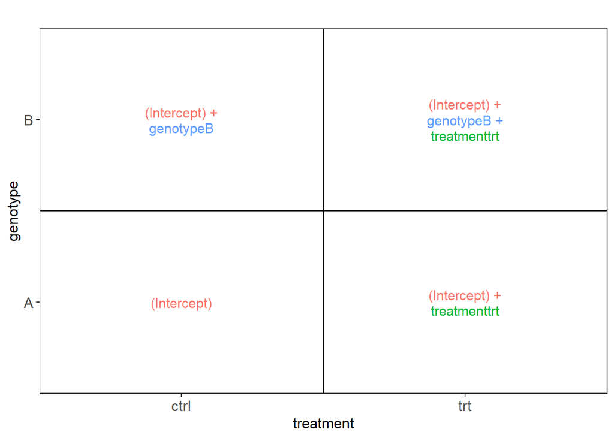

```r
## Creemos las imágenes usando ExploreModelMatrix
vd <- ExploreModelMatrix::VisualizeDesign(
    sampleData = sampleData,
    designFormula = ~ genotype + treatment,
    textSizeFitted = 4
)

## Veamos las imágenes
cowplot::plot_grid(plotlist = vd$plotlist)
```

De forma interactiva podemos correr el siguiente código:

```r
## Usaremos shiny otra ves
app <- ExploreModelMatrix(
    sampleData = sampleData,
    designFormula = ~ genotype + treatment
)
if (interactive()) shiny::runApp(app)
```

Podemos “restar cuadrantes” para quedarnos solo con los coeficientes que necesitemos para dar una interpretación.

### Ejemplo 2

http://bioconductor.org/packages/release/bioc/vignettes/ExploreModelMatrix/inst/doc/ExploreModelMatrix.html#example-2

### Ejemplo 3

http://bioconductor.org/packages/release/bioc/vignettes/ExploreModelMatrix/inst/doc/ExploreModelMatrix.html#example-3

### Ejercicio

- Interpreta `ResponseResistant.Treatmentpre` del ejercicio 2. Puede ser útil tomar un *screenshot* (captura de pantalla) y anotarla con líneas de colores. Si haces eso, puedes incluir la imagen en tus notas.

Podemos aislar `ResponseResistant.Treatmentpre` restando las columnas 1 y 2, pero solo en el escenario en el que la respuesta es igual a resistente.

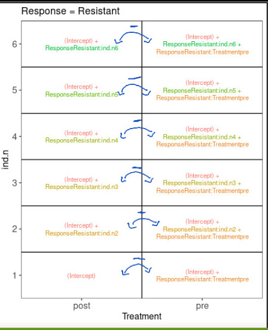

- ¿Por qué es clave el `0` al inicio de la fórmula en el ejercicio 3? Al añadir el cero cambia la interpretación de los batches. Si queremos incluir cada uno de los batches es necesario incluir el 0+, si quisiéramos hacerlos relativos contra el batch 1, quitamos el 0+.

### Para aprender más

*A guide to creating design matrices for gene expression experiments*:

- http://bioconductor.org/packages/release/workflows/vignettes/RNAseq123/inst/doc/designmatrices.html
- https://f1000research.com/articles/9-1444

*“Model matrix not full rank”*

- http://bioconductor.org/packages/release/bioc/vignettes/DESeq2/inst/doc/DESeq2.html#model-matrix-not-full-rank

## Datos de SRP045638

Vamos a usar datos de https://www.ncbi.nlm.nih.gov/sra/?term=SRP045638 procesados con `recount3`. Primero hay que descargar los datos con los comandos que vimos ayer.

```r
library("recount3")
# Bajamos los datos de recount3 y hacemos un subset del estudio que nos interesa.
human_projects <- available_projects()
```

```
## 2022-02-05 19:04:27 caching file sra.recount_project.MD.gz.
```

```
## 2022-02-05 19:04:29 caching file gtex.recount_project.MD.gz.
```

```
## 2022-02-05 19:04:30 caching file tcga.recount_project.MD.gz.
```

```r
rse_gene_SRP045638 <- create_rse(
    subset(
        human_projects,
        project == "SRP045638" & project_type == "data_sources"
    )
)
```

```
## 2022-02-05 19:04:45 downloading and reading the metadata.
```

```
## 2022-02-05 19:04:46 caching file sra.sra.SRP045638.MD.gz.
```

```
## 2022-02-05 19:04:48 caching file sra.recount_project.SRP045638.MD.gz.
```

```
## 2022-02-05 19:04:49 caching file sra.recount_qc.SRP045638.MD.gz.
```

```
## 2022-02-05 19:04:50 caching file sra.recount_seq_qc.SRP045638.MD.gz.
```

```
## 2022-02-05 19:04:52 caching file sra.recount_pred.SRP045638.MD.gz.
```

```
## 2022-02-05 19:04:53 downloading and reading the feature information.
```

```
## 2022-02-05 19:04:54 caching file human.gene_sums.G026.gtf.gz.
```

```
## 2022-02-05 19:04:55 downloading and reading the counts: 66 samples across 63856 features.
```

```
## 2022-02-05 19:04:56 caching file sra.gene_sums.SRP045638.G026.gz.
```

```
## 2022-02-05 19:04:59 construcing the RangedSummarizedExperiment (rse) object.
```

```r
# Convertimos los datos crudos de recount3 en el numero de lecturas con la función compute_read_counts y los almacenamos en el assay que llamaremos counts.
assay(rse_gene_SRP045638, "counts") <- compute_read_counts(rse_gene_SRP045638)
```

Una vez descargados y con los números de lecturas podemos usar `expand_sra_attributes()`. Sin embargo, tenemos un problema con estos datos.

```r
# Checamos la información, hay muestras tienen información que otras no.
rse_gene_SRP045638$sra.sample_attributes[1:3]
```

```
## [1] "age;;67.78|biomaterial_provider;;LIBD|BioSampleModel;;Human|dev_stage;;Fetal|disease;;Control|Fraction;;total|isolate;;DLPFC|race;;AA|RIN;;8.3|sex;;female|tissue;;DLPFC"
## [2] "age;;40.42|biomaterial_provider;;LIBD|BioSampleModel;;Human|disease;;Control|Fraction;;total|isolate;;DLPFC|race;;AA|RIN;;8.4|sex;;male|tissue;;DLPFC"
## [3] "age;;41.58|biomaterial_provider;;LIBD|BioSampleModel;;Human|disease;;control|Fraction;;total|isolate;;R2869|race;;AA|RIN;;8.7|sex;;male|tissue;;DLPFC"
```

Vamos a intentar resolverlo eliminando información que está presente solo en ciertas muestras.

```r
# Eliminamos la parte que nos da problemas.
rse_gene_SRP045638$sra.sample_attributes <- gsub("dev_stage;;Fetal\\|", "", rse_gene_SRP045638$sra.sample_attributes)
rse_gene_SRP045638$sra.sample_attributes[1:3]
```

```
## [1] "age;;67.78|biomaterial_provider;;LIBD|BioSampleModel;;Human|disease;;Control|Fraction;;total|isolate;;DLPFC|race;;AA|RIN;;8.3|sex;;female|tissue;;DLPFC"
## [2] "age;;40.42|biomaterial_provider;;LIBD|BioSampleModel;;Human|disease;;Control|Fraction;;total|isolate;;DLPFC|race;;AA|RIN;;8.4|sex;;male|tissue;;DLPFC"
## [3] "age;;41.58|biomaterial_provider;;LIBD|BioSampleModel;;Human|disease;;control|Fraction;;total|isolate;;R2869|race;;AA|RIN;;8.7|sex;;male|tissue;;DLPFC"
```

Ahora si podemos continuar con el mismo código de ayer.

```r
rse_gene_SRP045638 <- expand_sra_attributes(rse_gene_SRP045638)

colData(rse_gene_SRP045638)[
    ,
    grepl("^sra_attribute", colnames(colData(rse_gene_SRP045638)))
]
```

```
## DataFrame with 66 rows and 10 columns
##            sra_attribute.age sra_attribute.biomaterial_provider
##                  <character>                        <character>
## SRR2071341             67.78                               LIBD
## SRR2071345             40.42                               LIBD
## SRR2071346             41.58                               LIBD
## SRR2071347             44.17                               LIBD
## SRR2071348           -0.3836                               LIBD
## ...                      ...                                ...
## SRR2071366             66.72                               LIBD
## SRR2071372             43.88                               LIBD
## SRR2071373             15.17                               LIBD
## SRR2071374             70.95                               LIBD
## SRR2071375              4.14                               LIBD
##            sra_attribute.BioSampleModel sra_attribute.disease
##                             <character>           <character>
## SRR2071341                        Human               Control
## SRR2071345                        Human               Control
## SRR2071346                        Human               control
## SRR2071347                        Human               control
## SRR2071348                        Human               control
## ...                                 ...                   ...
## SRR2071366                        Human               control
## SRR2071372                        Human               control
## SRR2071373                        Human               control
## SRR2071374                        Human               control
## SRR2071375                        Human               control
##            sra_attribute.Fraction sra_attribute.isolate sra_attribute.race
##                       <character>           <character>        <character>
## SRR2071341                  total                 DLPFC                 AA
## SRR2071345                  total                 DLPFC                 AA
## SRR2071346                  total                 R2869                 AA
## SRR2071347                  total                 R3098                 AA
## SRR2071348                  total                 R3452                 AA
## ...                           ...                   ...                ...
## SRR2071366                  total                 R3763               CAUC
## SRR2071372                  total                 R4166                 AA
## SRR2071373                  total                 R4196               CAUC
## SRR2071374                  total                 R4338                 AS
## SRR2071375                  total                 R4699               CAUC
##            sra_attribute.RIN sra_attribute.sex sra_attribute.tissue
##                  <character>       <character>          <character>
## SRR2071341               8.3            female                DLPFC
## SRR2071345               8.4              male                DLPFC
## SRR2071346               8.7              male                DLPFC
## SRR2071347               5.3            female                DLPFC
## SRR2071348               9.6            female                DLPFC
## ...                      ...               ...                  ...
## SRR2071366                 7            female                DLPFC
## SRR2071372               8.7              male                DLPFC
## SRR2071373               7.9            female                DLPFC
## SRR2071374               8.3              male                DLPFC
## SRR2071375               8.7              male                DLPFC
```

Como ahora si vamos a usar esta información para un modelo estadístico, será importante que tengamos en el formato correcto de R a la información que vamos a usar.

```r
## Pasar de character a nuemric o factor
rse_gene_SRP045638$sra_attribute.age <- as.numeric(rse_gene_SRP045638$sra_attribute.age)
rse_gene_SRP045638$sra_attribute.disease <- factor(rse_gene_SRP045638$sra_attribute.disease)
rse_gene_SRP045638$sra_attribute.RIN <- as.numeric(rse_gene_SRP045638$sra_attribute.RIN)
rse_gene_SRP045638$sra_attribute.sex <- factor(rse_gene_SRP045638$sra_attribute.sex)

## Resumen de las variables de interés
summary(as.data.frame(colData(rse_gene_SRP045638)[
    ,
    grepl("^sra_attribute.[age|disease|RIN|sex]", colnames(colData(rse_gene_SRP045638)))
]))
```

```
##  sra_attribute.age sra_attribute.disease sra_attribute.isolate
##  Min.   :-0.4986   control:62            Length:66
##  1st Qu.: 0.3424   Control: 4            Class :character
##  Median :14.9000                         Mode  :character
##  Mean   :22.6286
##  3rd Qu.:41.2900
##  Max.   :73.9100
##  sra_attribute.RIN sra_attribute.sex
##  Min.   :5.30      female:22
##  1st Qu.:8.00      male  :44
##  Median :8.30
##  Mean   :8.15
##  3rd Qu.:8.70
##  Max.   :9.60
```

Ahora crearemos un par de variables para que las podamos usar en nuestro análisis.

```r
## Encontraremos diferencias entre muestra prenatalas vs postnatales
rse_gene_SRP045638$prenatal <- factor(ifelse(rse_gene_SRP045638$sra_attribute.age < 0, "prenatal", "postnatal"))
table(rse_gene_SRP045638$prenatal)
```

```
##
## postnatal  prenatal
##        56        10
```

```r
## http://rna.recount.bio/docs/quality-check-fields.html
rse_gene_SRP045638$assigned_gene_prop <- rse_gene_SRP045638$recount_qc.gene_fc_count_all.assigned / rse_gene_SRP045638$recount_qc.gene_fc_count_all.total
summary(rse_gene_SRP045638$assigned_gene_prop)
```

```
##    Min. 1st Qu.  Median    Mean 3rd Qu.    Max.
##  0.1942  0.7004  0.7591  0.7170  0.7991  0.8493
```

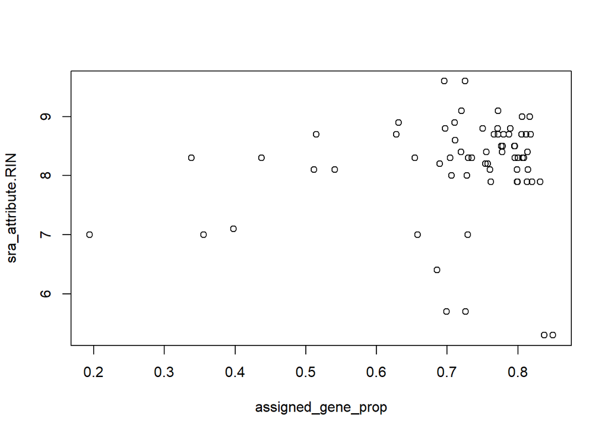

```r
with(colData(rse_gene_SRP045638), plot(assigned_gene_prop, sra_attribute.RIN))
```

```r
## Hm... veamos si hay una diferencia entre los grupos
with(colData(rse_gene_SRP045638), tapply(assigned_gene_prop, prenatal, summary))
```

```
## $postnatal
##    Min. 1st Qu.  Median    Mean 3rd Qu.    Max.
##  0.1942  0.7072  0.7719  0.7179  0.8017  0.8493
##
## $prenatal
##    Min. 1st Qu.  Median    Mean 3rd Qu.    Max.
##  0.6856  0.7004  0.7088  0.7116  0.7259  0.7347
```

A continuación podemos eliminar algunas muestras que consideremos de baja calidad y genes con niveles de expresión muy bajos.

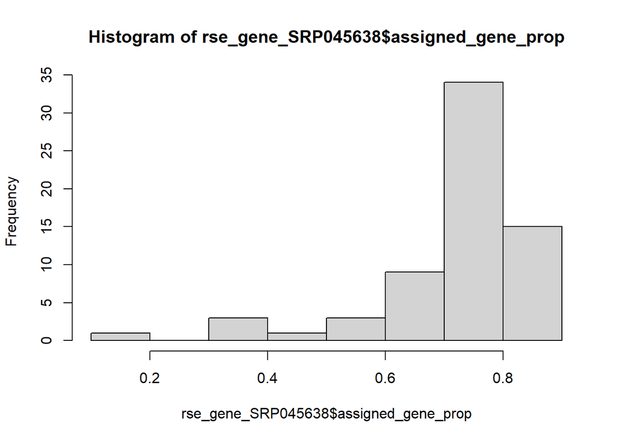

```r
## Guardemos nuestro objeto entero por si luego cambiamos de opinión
rse_gene_SRP045638_unfiltered <- rse_gene_SRP045638

## Eliminemos a muestras malas
hist(rse_gene_SRP045638$assigned_gene_prop)
```

```r
table(rse_gene_SRP045638$assigned_gene_prop < 0.3)
```

```
##
## FALSE  TRUE
##    65     1
```

```r
rse_gene_SRP045638 <- rse_gene_SRP045638[, rse_gene_SRP045638$assigned_gene_prop > 0.3]

## Calculemos los niveles medios de expresión de los genes en nuestras
## muestras.
## Ojo: en un análisis real probablemente haríamos esto con los RPKMs o CPMs
## en vez de las cuentas.
gene_means <- rowMeans(assay(rse_gene_SRP045638, "counts"))
summary(gene_means)
```

```
##      Min.   1st Qu.    Median      Mean   3rd Qu.      Max.
##       0.0       0.1       2.5     817.5     171.2 1362047.9
```

```r
## Eliminamos genes
rse_gene_SRP045638 <- rse_gene_SRP045638[gene_means > 0.1, ]

## Dimensiones finales
dim(rse_gene_SRP045638)
```

```
## [1] 46932    65
```

```r
## Porcentaje de genes que retuvimos
round(nrow(rse_gene_SRP045638) / nrow(rse_gene_SRP045638_unfiltered) * 100, 2)
```

```
## [1] 73.5
```

Ahora ya estamos listos para continuar con el análisis de expresión diferencial, bueno, casi.

## Normalización de datos

- Lean *A hypothetical scenario* en uno de los artículos sobre `edgeR` https://genomebiology.biomedcentral.com/articles/10.1186/gb-2010-11-3-r25#Sec2 para entender un poco sobre el concepto de *composition bias*.
- Sigue siendo relevante con datos de scRNA-seq como pueden ver en http://bioconductor.org/books/3.14/OSCA.multisample/multi-sample-comparisons.html#performing-the-de-analysis. Ahí descubren una serie de pasos para usar métodos desarrollados para bulk RNA-seq y como se pueden usar en scRNA-seq.

```r
library("edgeR") # BiocManager::install("edgeR", update = FALSE)
dge <- DGEList(
    counts = assay(rse_gene_SRP045638, "counts"),
    genes = rowData(rse_gene_SRP045638)
)
dge <- calcNormFactors(dge)
```

## Expresión diferencial

Primero que nada, definamos nuestro modelo estadístico. Típicamente, exploraríamos más los datos para revisar que no haya otros problemas con las muestras y para explorar la relación entre nuestras variables.

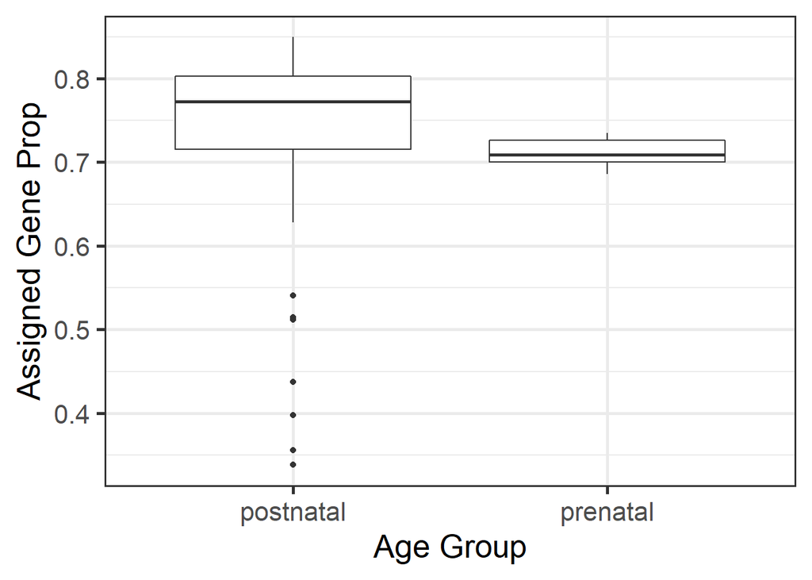

```r
library("ggplot2")
ggplot(as.data.frame(colData(rse_gene_SRP045638)), aes(y = assigned_gene_prop, x = prenatal)) +
    geom_boxplot() +
    theme_bw(base_size = 20) +
    ylab("Assigned Gene Prop") +
    xlab("Age Group")
```

Por ejemplo, usando el paquete de [`variancePartition`](https://bioconductor.org/packages/variancePartition) y [`scater`](https://bioconductor.org/packages/scater) entre otros tal como exploramos en el siguiente video del club de R de LIBD (*[notes in English](https://docs.google.com/document/d/1hil3zwPN6BW6HlwldLbM1FdlLIBWKFNXRUqJJEK_-eY/edit)*)/

[video not shown]

Por ahora continuaremos con el siguiente modelo estadístico.

```r
mod <- model.matrix(~ prenatal + sra_attribute.RIN + sra_attribute.sex + assigned_gene_prop,
    data = colData(rse_gene_SRP045638)
)
colnames(mod)
```

```
## [1] "(Intercept)"           "prenatalprenatal"      "sra_attribute.RIN"
## [4] "sra_attribute.sexmale" "assigned_gene_prop"
```

En este caso, una de las columnas se llamna “prenatalprenatal” porque tenemos una variable que se llama “prenatal” que tiene dos opciones: pre y postnatal, si las ordenamos en orden alfabético va a ir primero postnatal, entonces será el valor de referencia. Este coeficiente nos muestra la diferencia de prenatal - postnatal. Nos está mostrando el contraste, no el grupo de referencia.

Ya teniendo el modelo estadístico, podemos usar `limma` para realizar el análisis de expresión diferencial como tal.

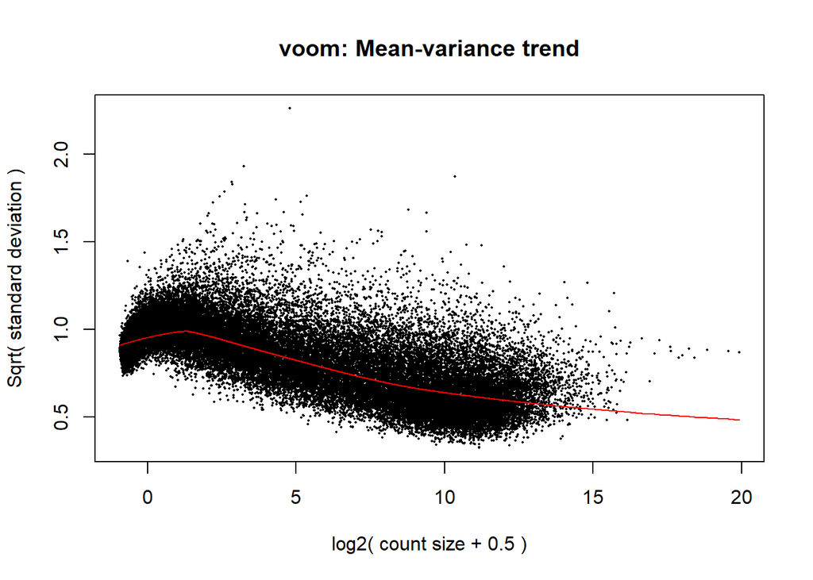

```r
library("limma")
vGene <- voom(dge, mod, plot = TRUE) # Está gráfica ve la relación entre el promedio de expresión (x) y la varianza (y).
```

```r
eb_results <- eBayes(lmFit(vGene))

# topTable nos sirve para escoger un coeficiente de nuestro interés. El número de columna de nuestro modelo. Los argumentos number y sort.by es necesario dejarlos siempre igual
de_results <- topTable(
    eb_results,
    coef = 2,
    number = nrow(rse_gene_SRP045638),
    sort.by = "none"
)
dim(de_results)
```

```
## [1] 46932    16
```

```r
head(de_results)
```

```
##                    source type bp_length phase           gene_id
## ENSG00000223972.5  HAVANA gene      1735    NA ENSG00000223972.5
## ENSG00000278267.1 ENSEMBL gene        68    NA ENSG00000278267.1
## ENSG00000227232.5  HAVANA gene      1351    NA ENSG00000227232.5
## ENSG00000284332.1 ENSEMBL gene       138    NA ENSG00000284332.1
## ENSG00000243485.5  HAVANA gene      1021    NA ENSG00000243485.5
## ENSG00000237613.2  HAVANA gene      1219    NA ENSG00000237613.2
##                                            gene_type   gene_name level
## ENSG00000223972.5 transcribed_unprocessed_pseudogene     DDX11L1     2
## ENSG00000278267.1                              miRNA   MIR6859-1     3
## ENSG00000227232.5             unprocessed_pseudogene      WASH7P     2
## ENSG00000284332.1                              miRNA   MIR1302-2     3
## ENSG00000243485.5                            lincRNA MIR1302-2HG     2
## ENSG00000237613.2                            lincRNA     FAM138A     2
##                            havana_gene        tag      logFC    AveExpr
## ENSG00000223972.5 OTTHUMG00000000961.2       <NA> -0.4464473 -3.4480071
## ENSG00000278267.1                 <NA>       <NA>  1.1238124 -1.3154875
## ENSG00000227232.5 OTTHUMG00000000958.1       <NA>  0.6932616  3.6372886
## ENSG00000284332.1                 <NA>       <NA>  0.4646765 -5.7349490
## ENSG00000243485.5 OTTHUMG00000000959.2 ncRNA_host  0.9705984 -0.6684675
## ENSG00000237613.2 OTTHUMG00000000960.1       <NA> -1.5393441 -5.3057586
##                           t      P.Value    adj.P.Val          B
## ENSG00000223972.5 -1.616387 1.108073e-01 1.399351e-01 -5.5871402
## ENSG00000278267.1  6.175776 4.669176e-08 1.730504e-07  7.9671608
## ENSG00000227232.5  5.723387 2.807302e-07 9.348513e-07  5.8016259
## ENSG00000284332.1  1.467797 1.469350e-01 1.811388e-01 -5.7535500
## ENSG00000243485.5  5.110633 2.985939e-06 8.551661e-06  3.8413461
## ENSG00000237613.2 -4.169751 9.126976e-05 1.967694e-04  0.8591194
```

```r
## Genes diferencialmente expresados entre pre y post natal con FDR < 5%
table(de_results$adj.P.Val < 0.05)
```

```
##
## FALSE  TRUE
## 12898 34034
```

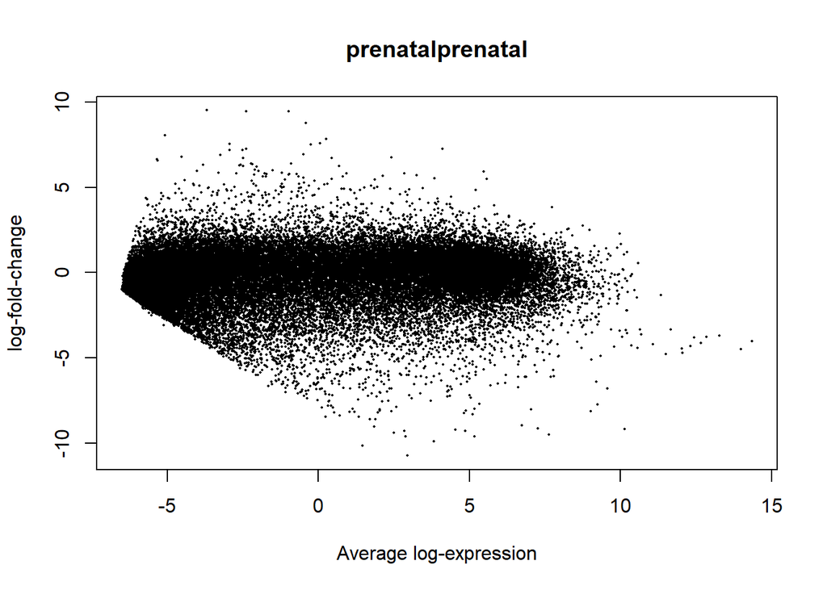

```r
## Visualicemos los resultados estadísticos
plotMA(eb_results, coef = 2)
```

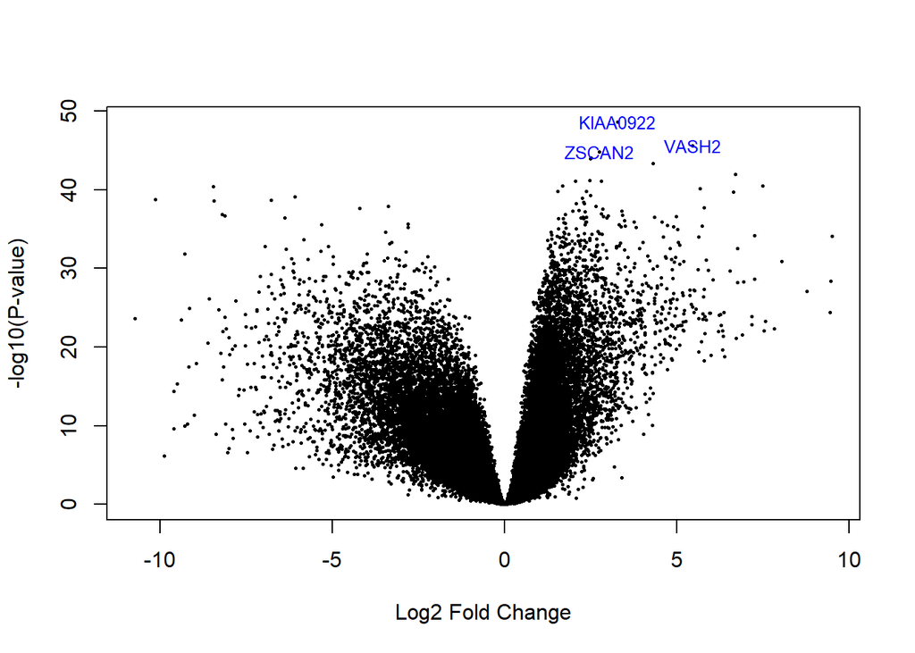

```r
volcanoplot(eb_results, coef = 2, highlight = 3, names = de_results$gene_name)
```

```r
de_results[de_results$gene_name %in% c("ZSCAN2", "VASH2", "KIAA0922"), ]
```

```
##                    source type bp_length phase            gene_id
## ENSG00000143494.15 HAVANA gene      9086    NA ENSG00000143494.15
## ENSG00000176371.13 HAVANA gene      4878    NA ENSG00000176371.13
## ENSG00000121210.15 HAVANA gene      6393    NA ENSG00000121210.15
##                         gene_type gene_name level          havana_gene  tag
## ENSG00000143494.15 protein_coding     VASH2     2 OTTHUMG00000036925.5 <NA>
## ENSG00000176371.13 protein_coding    ZSCAN2     1 OTTHUMG00000074027.5 <NA>
## ENSG00000121210.15 protein_coding  KIAA0922     2 OTTHUMG00000153244.5 <NA>
##                       logFC  AveExpr        t      P.Value    adj.P.Val
## ENSG00000143494.15 5.451644 1.873147 37.90413 2.394912e-46 5.619900e-42
## ENSG00000176371.13 2.742707 2.747266 36.79465 1.543986e-45 2.415411e-41
## ENSG00000121210.15 3.290165 2.941427 42.25191 2.535399e-49 1.189913e-44
##                            B
## ENSG00000143494.15  95.16926
## ENSG00000176371.13  93.31745
## ENSG00000121210.15 101.80839
```

- https://www.genecards.org/cgi-bin/carddisp.pl?gene=ZSCAN2
- https://www.genecards.org/cgi-bin/carddisp.pl?gene=VASH2
- https://www.genecards.org/cgi-bin/carddisp.pl?gene=KIAA0922

## Visualizando genes DE

De `vGene$E` podemos extraer los datos normalizados por `limma-voom`. Revisemos los top 50 genes diferencialmente expresados.

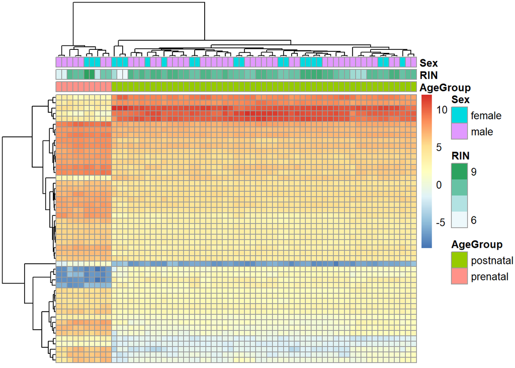

```r
## Extraer valores de los genes de interés
exprs_heatmap <- vGene$E[rank(de_results$adj.P.Val) <= 50, ]

## Creemos una tabla con información de las muestras
## y con nombres de columnas más amigables
df <- as.data.frame(colData(rse_gene_SRP045638)[, c("prenatal", "sra_attribute.RIN", "sra_attribute.sex")])
colnames(df) <- c("AgeGroup", "RIN", "Sex")

## Hagamos un heatmap
library("pheatmap")
pheatmap(
    exprs_heatmap,
    # Agrupar genes
    cluster_rows = TRUE,
    # Agrupar muestras
    cluster_cols = TRUE,
    show_rownames = FALSE,
    show_colnames = FALSE,
    annotation_col = df
)
```

Los resultados que tenemos no son tan sorprendentes porque hay una diferencia enorme en los perfiles de expresión en el DLPFC entre muestra pre y post-natales. Eso lo podemos ver con MDS (multidimensional scaling) tal como describen en [este workflow](http://bioconductor.org/packages/release/workflows/vignettes/RNAseq123/inst/doc/limmaWorkflow.html#unsupervised-clustering-of-samples).

```r
## Para colores
library("RColorBrewer")

## Conviertiendo los grupos de edad a colores
col.group <- df$AgeGroup
levels(col.group) <- brewer.pal(nlevels(col.group), "Set1")
```

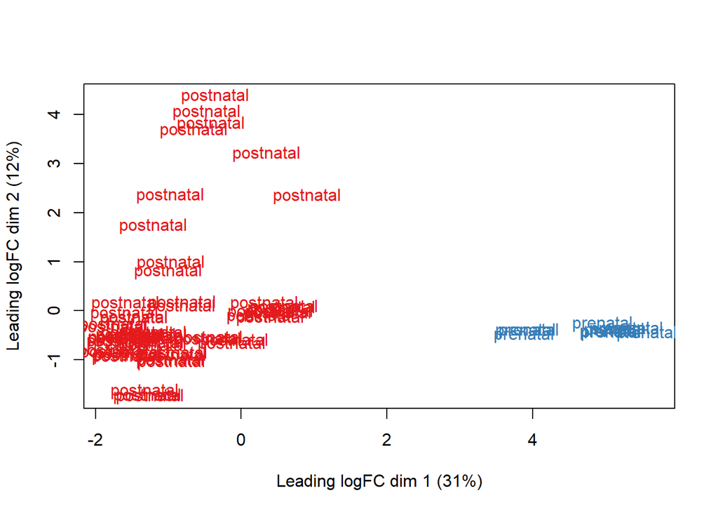

```r
col.group <- as.character(col.group)

## MDS por grupos de edad
plotMDS(vGene$E, labels = df$AgeGroup, col = col.group)
```

```r
## Conviertiendo los valores de Sex a colores
col.sex <- df$Sex
levels(col.sex) <- brewer.pal(nlevels(col.sex), "Dark2")
```

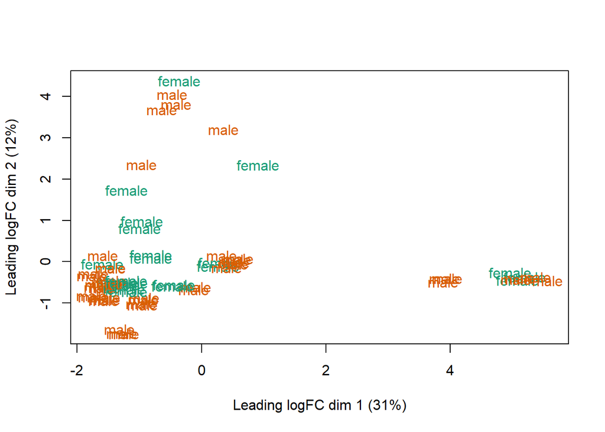

```r
col.sex <- as.character(col.sex)

## MDS por sexo
plotMDS(vGene$E, labels = df$Sex, col = col.sex)
```

## Ejercicio

Agreguen los nombres de los genes a nuestro `pheatmap`.

Pistas:

- Revisen la información de `rowRanges(rse_gene_SRP045638)` o `de_results`.
- Exploren que hace la función `match()`.

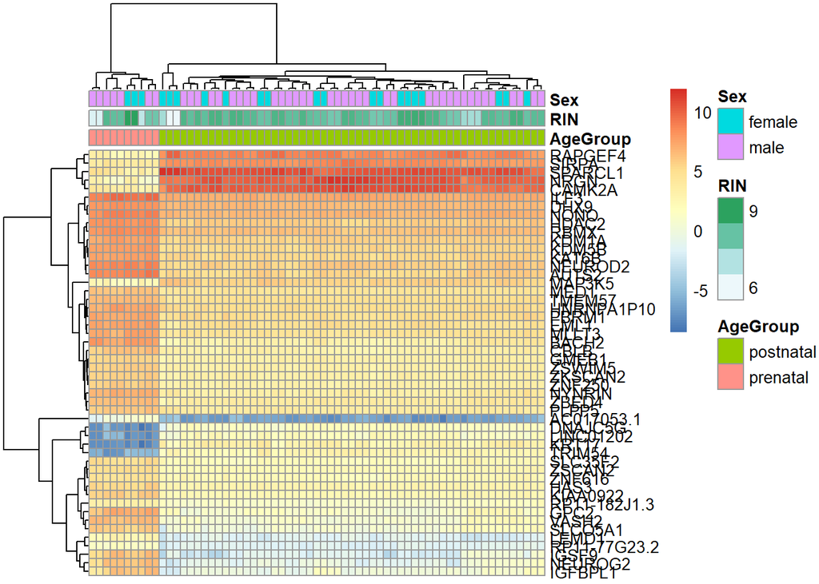

```r
v <-match(rownames(exprs_heatmap), de_results$gene_id)

nombres_humanos<-de_results$gene_name[v]

rownames(exprs_heatmap) <- nombres_humanos

pheatmap(exprs_heatmap, cluster_rows = TRUE, cluster_cols = TRUE, show_rownames = TRUE, show_colnames = FALSE, annotation_col = df)
```

```r
pdf("pheatmap_con_nombres.pdf", height = 14, useDingbats = FALSE)
pheatmap(exprs_heatmap, cluster_rows = TRUE, cluster_cols = TRUE, show_rownames = TRUE, show_colnames = FALSE, annotation_col = df)

dev.off()
```

## Comunidad

Algunxs de lxs autores de `ExploreModelMatrix`:

- https://twitter.com/CSoneson
- https://twitter.com/FedeBioinfo
- https://twitter.com/mikelove

Algunxs de lxs autores de `edgeR` y `limma`:

- https://twitter.com/mritchieau
- https://twitter.com/davisjmcc
- https://twitter.com/markrobinsonca
- https://twitter.com/AliciaOshlack